# STEVEN

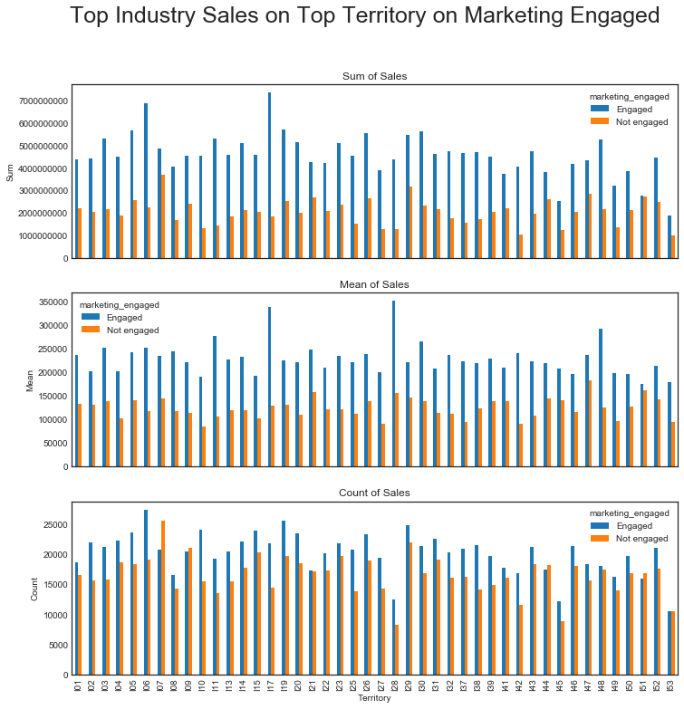

```python
# Top industry sales on top territory on marketing engaged
fig, axes = plt.subplots(nrows=3, ncols=1,sharex=True,figsize=(12, 12))
axes[0].ticklabel_format(useOffset=False,style='plain')
axes[1].ticklabel_format(useOffset=False,style='plain')
axes[2].ticklabel_format(useOffset=False,style='plain')
pd.crosstab(df_terr_top['territory'],df_terr_top['marketing_engaged'],df_terr_top["total_industry_sales"],aggfunc='sum').plot(ax=axes[0], kind='bar',title="Sum of Sales")
pd.crosstab(df_terr_top['territory'],df_terr_top['marketing_engaged'],df_terr_top["total_industry_sales"],aggfunc='mean').plot(ax=axes[1], kind='bar',title="Mean of Sales")
pd.crosstab(df_terr_top['territory'],df_terr_top['marketing_engaged'],df_terr_top["total_industry_sales"],aggfunc='count').plot(ax=axes[2], kind='bar',title="Count of Sales")
plt.xticks(rotation = 90)
plt.xlabel("Territory")
plt.setp(axes[0], ylabel='Sum')
plt.setp(axes[1], ylabel='Mean')
plt.setp(axes[2], ylabel='Count')
plt.suptitle("Top Industry Sales on Top Territory on Marketing Engaged",size = 25)
plt.show()
```

Fund Category Category

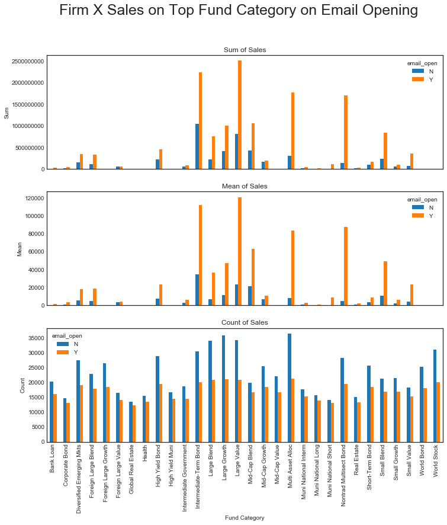

```python
df_fundcategory_top.reset_index(inplace=True)
matching_id = df['fund_category'].isin(df_fundcategory_top['fund_category'])
df_fund_top = df.loc[matching_id, :]
fig, axes = plt.subplots(nrows=3, ncols=1,sharex=True,figsize=(12, 12))
axes[0].ticklabel_format(useOffset=False,style='plain')
pd.crosstab(df_fund_top['fund_category'],df_fund_top['email_open'],df_fund_top["firm_x_sales"],aggfunc='sum').plot(ax=axes[0], kind='bar',title="Sum of Sales")
pd.crosstab(df_fund_top['fund_category'],df_fund_top['email_open'],df_fund_top["firm_x_sales"],aggfunc='mean').plot(ax=axes[1], kind='bar',title="Mean of Sales")
pd.crosstab(df_fund_top['fund_category'],df_fund_top['email_open'],df_fund_top["firm_x_sales"],aggfunc='count').plot(ax=axes[2], kind='bar',title="Count of Sales")
plt.xticks(rotation = 90)
plt.xlabel("Fund Category")
plt.setp(axes[0], ylabel='Sum')
plt.setp(axes[1], ylabel='Mean')
plt.setp(axes[2], ylabel='Count')
plt.suptitle("Firm X Sales on Top Fund Category on Email Opening",size = 25)
plt.show()
```

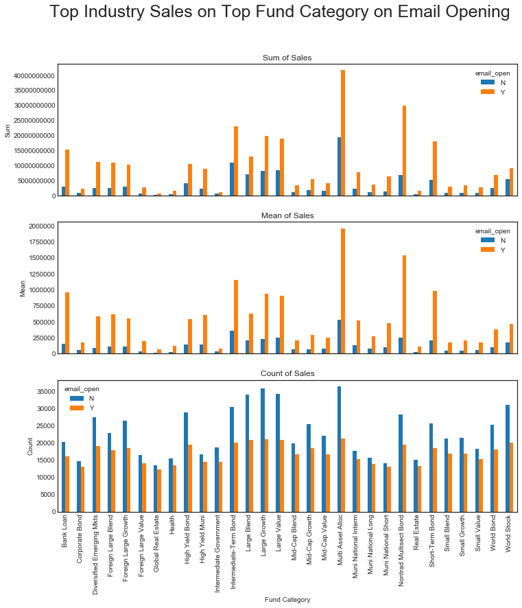

```python
# Top industry sales on top category on email opening
fig, axes = plt.subplots(nrows=3, ncols=1,sharex=True,figsize=(12, 12))
axes[0].ticklabel_format(useOffset=False,style='plain')
axes[1].ticklabel_format(useOffset=False,style='plain')
axes[2].ticklabel_format(useOffset=False,style='plain')
pd.crosstab(df_fund_top['fund_category'],df_fund_top['email_open'],df_fund_top["total_industry_sales"],aggfunc='sum').plot(ax=axes[0], kind='bar',title="Sum of Sales")
pd.crosstab(df_fund_top['fund_category'],df_fund_top['email_open'],df_fund_top["total_industry_sales"],aggfunc='mean').plot(ax=axes[1], kind='bar',title="Mean of Sales")
pd.crosstab(df_fund_top['fund_category'],df_fund_top['email_open'],df_fund_top["total_industry_sales"],aggfunc='count').plot(ax=axes[2], kind='bar',title="Count of Sales")
plt.xticks(rotation = 90)
plt.xlabel("Fund Category")
plt.setp(axes[0], ylabel='Sum')
plt.setp(axes[1], ylabel='Mean')
plt.setp(axes[2], ylabel='Count')
plt.suptitle("Top Industry Sales on Top Fund Category on Email Opening",size = 25)
plt.show()
```

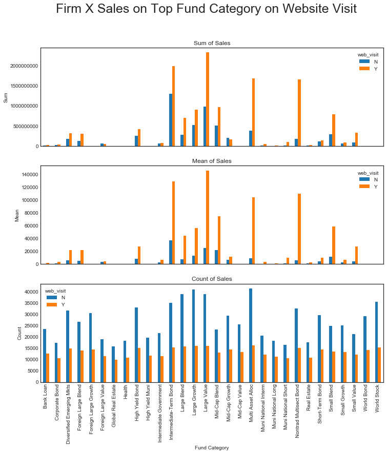

```python
# Firm X sales on Top fund category on website visit
fig, axes = plt.subplots(nrows=3, ncols=1,sharex=True,figsize=(12, 12))
axes[0].ticklabel_format(useOffset=False,style='plain')
axes[1].ticklabel_format(useOffset=False,style='plain')
axes[2].ticklabel_format(useOffset=False,style='plain')
pd.crosstab(df_fund_top['fund_category'],df_fund_top['web_visit'],df_fund_top["firm_x_sales"],aggfunc='sum').plot(ax=axes[0], kind='bar',title="Sum of Sales")
pd.crosstab(df_fund_top['fund_category'],df_fund_top['web_visit'],df_fund_top["firm_x_sales"],aggfunc='mean').plot(ax=axes[1], kind='bar',title="Mean of Sales")
pd.crosstab(df_fund_top['fund_category'],df_fund_top['web_visit'],df_fund_top["firm_x_sales"],aggfunc='count').plot(ax=axes[2], kind='bar',title="Count of Sales")
plt.xticks(rotation = 90)
plt.xlabel("Fund Category")
plt.setp(axes[0], ylabel='Sum')
plt.setp(axes[1], ylabel='Mean')
plt.setp(axes[2], ylabel='Count')
plt.suptitle("Firm X Sales on Top Fund Category on Website Visit",size = 25)
plt.show()
```

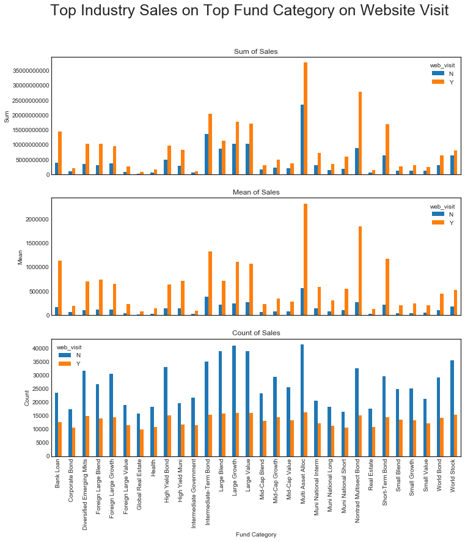

```python
# Top industry sales on top fund category on website visit
fig, axes = plt.subplots(nrows=3, ncols=1,sharex=True,figsize=(12, 12))
axes[0].ticklabel_format(useOffset=False,style='plain')
axes[1].ticklabel_format(useOffset=False,style='plain')
axes[2].ticklabel_format(useOffset=False,style='plain')
pd.crosstab(df_fund_top['fund_category'],df_fund_top['web_visit'],df_fund_top["total_industry_sales"],aggfunc='sum').plot(ax=axes[0], kind='bar',title="Sum of Sales")
pd.crosstab(df_fund_top['fund_category'],df_fund_top['web_visit'],df_fund_top["total_industry_sales"],aggfunc='mean').plot(ax=axes[1], kind='bar',title="Mean of Sales")
pd.crosstab(df_fund_top['fund_category'],df_fund_top['web_visit'],df_fund_top["total_industry_sales"],aggfunc='count').plot(ax=axes[2], kind='bar',title="Count of Sales")
plt.xticks(rotation = 90)
plt.xlabel("Fund Category")
plt.setp(axes[0], ylabel='Sum')
plt.setp(axes[1], ylabel='Mean')
plt.setp(axes[2], ylabel='Count')
plt.suptitle("Top Industry Sales on Top Fund Category on Website Visit",size = 25)
plt.show()
```

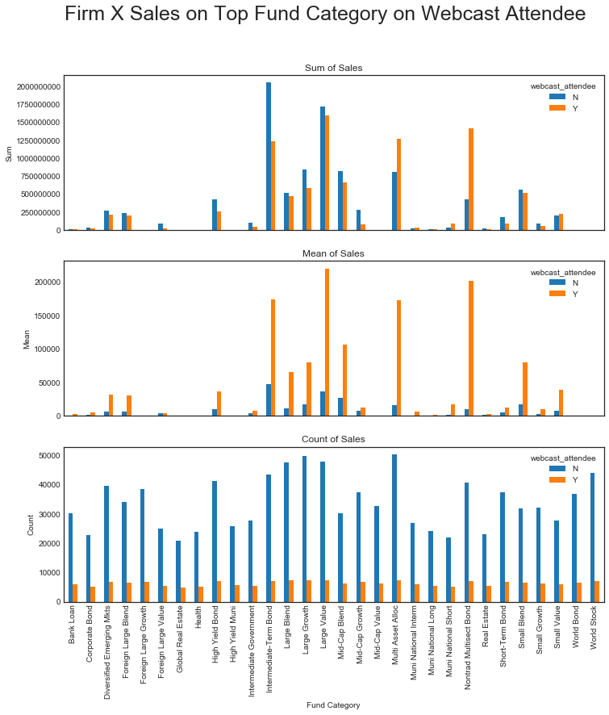

```python
# Firm X sales on Top fund category on webcast attendee
fig, axes = plt.subplots(nrows=3, ncols=1,sharex=True,figsize=(12, 12))
axes[0].ticklabel_format(useOffset=False,style='plain')
axes[1].ticklabel_format(useOffset=False,style='plain')
axes[2].ticklabel_format(useOffset=False,style='plain')
pd.crosstab(df_fund_top['fund_category'],df_fund_top['webcast_attendee'],df_fund_top["firm_x_sales"],aggfunc='sum').plot(ax=axes[0], kind='bar',title="Sum of Sales")
pd.crosstab(df_fund_top['fund_category'],df_fund_top['webcast_attendee'],df_fund_top["firm_x_sales"],aggfunc='mean').plot(ax=axes[1], kind='bar',title="Mean of Sales")
pd.crosstab(df_fund_top['fund_category'],df_fund_top['webcast_attendee'],df_fund_top["firm_x_sales"],aggfunc='count').plot(ax=axes[2], kind='bar',title="Count of Sales")
plt.xticks(rotation = 90)
plt.xlabel("Fund Category")
plt.setp(axes[0], ylabel='Sum')
plt.setp(axes[1], ylabel='Mean')
plt.setp(axes[2], ylabel='Count')
plt.suptitle("Firm X Sales on Top Fund Category on Webcast Attendee",size = 25)
plt.show()
```

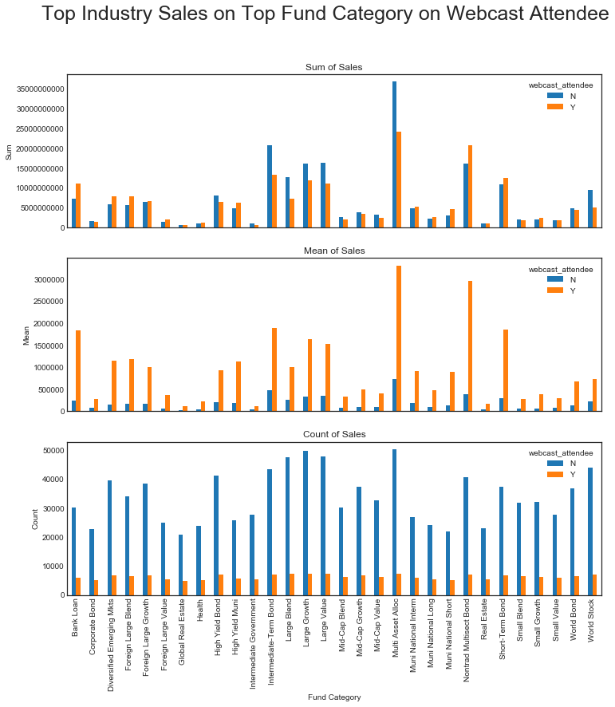

```python
# Top industry sales on Top fund category on webcast attendee

fig, axes = plt.subplots(nrows=3, ncols=1,sharex=True,figsize=(12, 12))
axes[0].ticklabel_format(useOffset=False,style='plain')
axes[1].ticklabel_format(useOffset=False,style='plain')
axes[2].ticklabel_format(useOffset=False,style='plain')
pd.crosstab(df_fund_top['fund_category'],df_fund_top['webcast_attendee'],df_fund_top["total_industry_sales"],aggfunc='sum').plot(ax=axes[0], kind='bar',title="Sum of Sales")
pd.crosstab(df_fund_top['fund_category'],df_fund_top['webcast_attendee'],df_fund_top["total_industry_sales"],aggfunc='mean').plot(ax=axes[1], kind='bar',title="Mean of Sales")
pd.crosstab(df_fund_top['fund_category'],df_fund_top['webcast_attendee'],df_fund_top["total_industry_sales"],aggfunc='count').plot(ax=axes[2], kind='bar',title="Count of Sales")
plt.xticks(rotation = 90)
plt.xlabel("Fund Category")
plt.setp(axes[0], ylabel='Sum')
plt.setp(axes[1], ylabel='Mean')
plt.setp(axes[2], ylabel='Count')
plt.suptitle("Top Industry Sales on Top Fund Category on Webcast Attendee",size = 25)
plt.show()
```

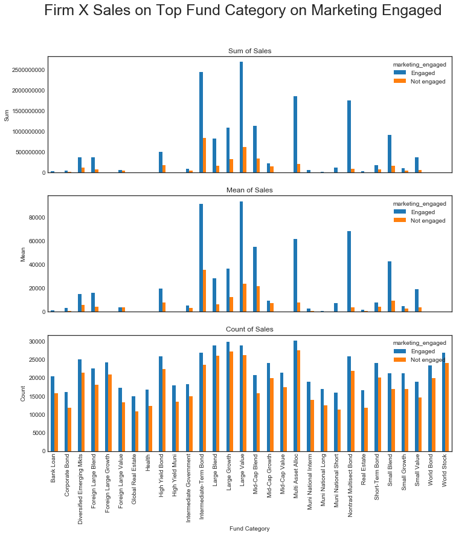

```python
# Firm X sales on Top fund category on marketing engaged

fig, axes = plt.subplots(nrows=3, ncols=1,sharex=True,figsize=(12, 12))
axes[0].ticklabel_format(useOffset=False,style='plain')
axes[1].ticklabel_format(useOffset=False,style='plain')
axes[2].ticklabel_format(useOffset=False,style='plain')
pd.crosstab(df_fund_top['fund_category'],df_fund_top['marketing_engaged'],df_fund_top["firm_x_sales"],aggfunc='sum').plot(ax=axes[0], kind='bar',title="Sum of Sales")
pd.crosstab(df_fund_top['fund_category'],df_fund_top['marketing_engaged'],df_fund_top["firm_x_sales"],aggfunc='mean').plot(ax=axes[1], kind='bar',title="Mean of Sales")
pd.crosstab(df_fund_top['fund_category'],df_fund_top['marketing_engaged'],df_fund_top["firm_x_sales"],aggfunc='count').plot(ax=axes[2], kind='bar',title="Count of Sales")
plt.xticks(rotation = 90)
plt.xlabel("Fund Category")
plt.setp(axes[0], ylabel='Sum')
plt.setp(axes[1], ylabel='Mean')
plt.setp(axes[2], ylabel='Count')
plt.suptitle("Firm X Sales on Top Fund Category on Marketing Engaged",size = 25)
plt.show()
```

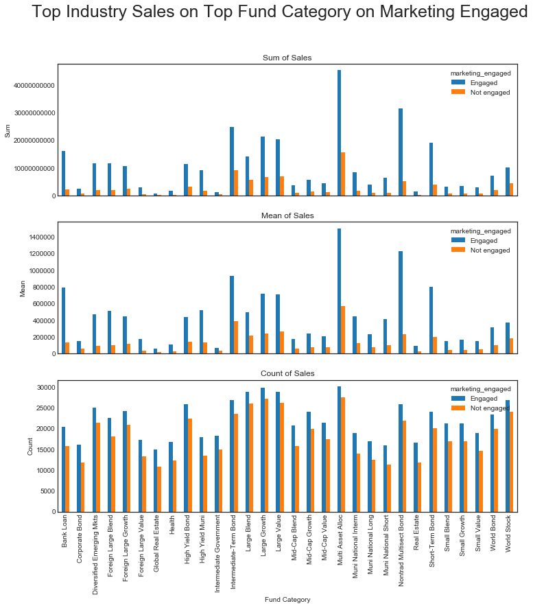

```python
# Top industry sales on top fund category on marketing engaged
fig, axes = plt.subplots(nrows=3, ncols=1,sharex=True,figsize=(12, 12))
axes[0].ticklabel_format(useOffset=False,style='plain')
axes[1].ticklabel_format(useOffset=False,style='plain')
axes[2].ticklabel_format(useOffset=False,style='plain')
pd.crosstab(df_fund_top['fund_category'],df_fund_top['marketing_engaged'],df_fund_top["total_industry_sales"],aggfunc='sum').plot(ax=axes[0], kind='bar',title="Sum of Sales")
pd.crosstab(df_fund_top['fund_category'],df_fund_top['marketing_engaged'],df_fund_top["total_industry_sales"],aggfunc='mean').plot(ax=axes[1], kind='bar',title="Mean of Sales")
pd.crosstab(df_fund_top['fund_category'],df_fund_top['marketing_engaged'],df_fund_top["total_industry_sales"],aggfunc='count').plot(ax=axes[2], kind='bar',title="Count of Sales")
plt.xticks(rotation = 90)
plt.xlabel("Fund Category")
plt.setp(axes[0], ylabel='Sum')
plt.setp(axes[1], ylabel='Mean')
plt.setp(axes[2], ylabel='Count')
plt.suptitle("Top Industry Sales on Top Fund Category on Marketing Engaged",size = 25)
plt.show()
```

Conclusion: It can therefore be concluded that the Broker 1 and 5 are the best brokers in the category in terms of sum and mean respectively.

Moreover, it can be said that Medium and Large value funds are good for the firm and Multi-class asset allocation is beneficial for the industry.

In the interaction, it can be observed that the email opening, website visitations and marketing engagement tend to have a higher sales in both the firm and the industry, but the webcast attendees is not a prominent variable in this regard.